# Heart Disease Risk Prediction Using Machine Learning in R

D.M.D.A.Dissanayaka (2020/ASP/83)

2026-11-17

## 1. Introduction

Heart disease is the leading cause of death worldwide, responsible for 17.9 million deaths annually (WHO, 2023). Early identification of high-risk patients using routine clinical measurements can assist clinicians in making faster diagnostic decisions. This project aims to predict the presence of coronary artery disease using machine learning models applied to clinical data from the Cleveland Heart Disease Dataset.

## 2. Data

The Cleveland Heart Disease Dataset was collected in 1988 at the Cleveland Clinic Foundation and published by Detrano et al. (1989) in the American Journal of Cardiology. It is publicly available from the UCI Machine Learning Repository. The dataset contains 303 patients and 14 clinical variables including age, sex, chest pain type, resting blood pressure, cholesterol, fasting blood sugar, resting ECG results, maximum heart rate, exercise induced angina, ST depression, slope, number of vessels, thalassemia type and the target variable indicating presence of heart disease.

## 3. Data Import and Cleaning

```r
# Load all required packages
library(ggplot2)
library(caret)
library(e1071)
library(pheatmap)
library(pROC)
library(randomForest)
```

```r
# Load the dataset
df <- read.csv("C:/Users/ADMIN/Documents/Bioinformatic-Project---2020-ASP-83/Data/heart.csv")

# Check size
dim(df)
```

```
## [1] 303  14
```

```r
# Check for missing values
sum(is.na(df))
```

```
## [1] 0
```

```r
# Convert categorical variables to factors
df$sex <- factor(df$sex, levels = c(0,1), labels = c("Female", "Male"))
df$cp <- factor(df$cp, levels = c(0,1,2,3), labels = c("Typical Angina", "Atypical Angina", "Non-anginal", "Asymptomatic"))
df$fbs <- factor(df$fbs, levels = c(0,1), labels = c("No", "Yes"))
df$restecg <- factor(df$restecg, levels = c(0,1,2), labels = c("Normal", "Abnormal", "Hypertrophy"))
df$exang <- factor(df$exang, levels = c(0,1), labels = c("No", "Yes"))
df$target <- factor(df$target, levels = c(0,1), labels = c("No Disease", "Heart Disease"))

# Check cleaned data
str(df)
```

```
## 'data.frame':    303 obs. of  14 variables:
##  $ age     : int  63 37 41 56 57 57 56 44 52 57 ...
##  $ sex     : Factor w/ 2 levels "Female","Male": 2 2 1 2 1 2 1 2 2 2 ...
##  $ cp      : Factor w/ 4 levels "Typical Angina",..: 4 3 2 2 1 1 2 2 3 3 ...
##  $ trestbps: int  145 130 130 120 120 140 140 120 172 150 ...
##  $ chol    : int  233 250 204 236 354 192 294 263 199 168 ...
##  $ fbs     : Factor w/ 2 levels "No","Yes": 2 1 1 1 1 1 1 1 2 1 ...
##  $ restecg : Factor w/ 3 levels "Normal","Abnormal",..: 1 2 1 2 2 2 1 2 2 2 ...
##  $ thalach : int  150 187 172 178 163 148 153 173 162 174 ...
##  $ exang   : Factor w/ 2 levels "No","Yes": 1 1 1 1 2 1 1 1 1 1 ...
##  $ oldpeak : num  2.3 3.5 1.4 0.8 0.6 0.4 1.3 0 0.5 1.6 ...
##  $ slope   : int  0 0 2 2 2 1 1 2 2 2 ...
##  $ ca      : int  0 0 0 0 0 0 0 0 0 0 ...
##  $ thal    : int  1 2 2 2 2 1 2 3 3 2 ...
##  $ target  : Factor w/ 2 levels "No Disease","Heart Disease": 2 2 2 2 2 2 2 2 2 2 ...
```

## 4. Exploratory Data Analysis

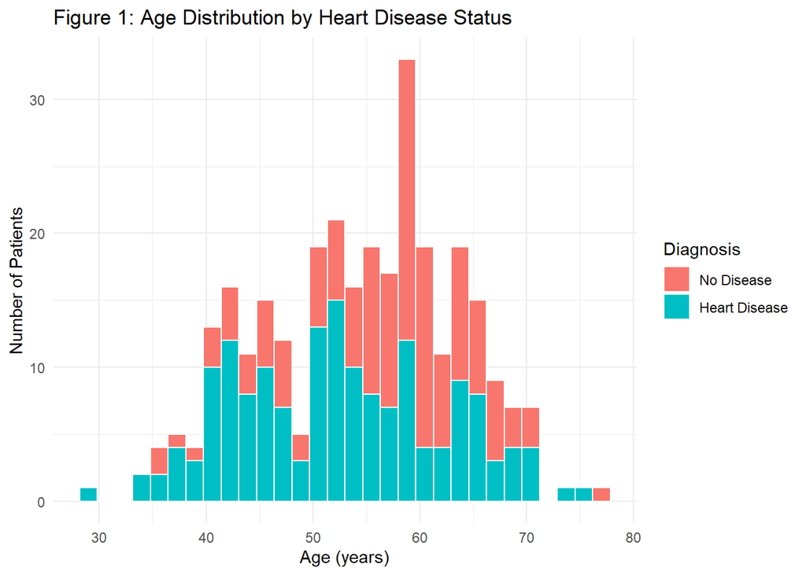

```r
# Figure 1 - Age distribution by heart disease outcome
plot1 <- ggplot(df, aes(x = age, fill = target)) +
  geom_histogram(bins = 30, color = "white") +
  labs(
    title = "Figure 1: Age Distribution by Heart Disease Status",
    x = "Age (years)",
    y = "Number of Patients",
    fill = "Diagnosis"
  ) +
  theme_minimal()

print(plot1)
```

```r
ggsave("C:/Users/ADMIN/Documents/Bioinformatic-Project---2020-ASP-83/Output/figure1_age_distribution.png",
       plot1, width = 8, height = 5)
```

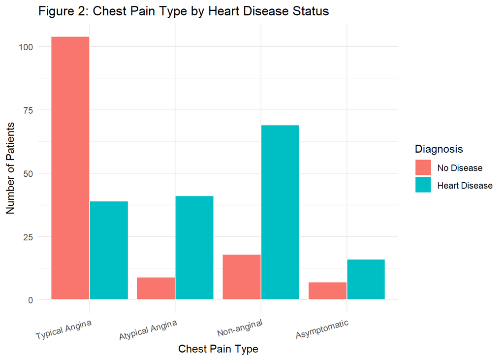

```r
# Figure 2 - Chest pain type by heart disease outcome
plot2 <- ggplot(df, aes(x = cp, fill = target)) +
  geom_bar(position = "dodge", color = "white") +
  labs(
    title = "Figure 2: Chest Pain Type by Heart Disease Status",
    x = "Chest Pain Type",
    y = "Number of Patients",
    fill = "Diagnosis"
  ) +
  theme_minimal() +
  theme(axis.text.x = element_text(angle = 15, hjust = 1))

print(plot2)
```

```r
ggsave("C:/Users/ADMIN/Documents/Bioinformatic-Project---2020-ASP-83/Output/figure2_chest_pain.png",
       plot2, width = 8, height = 5)
```

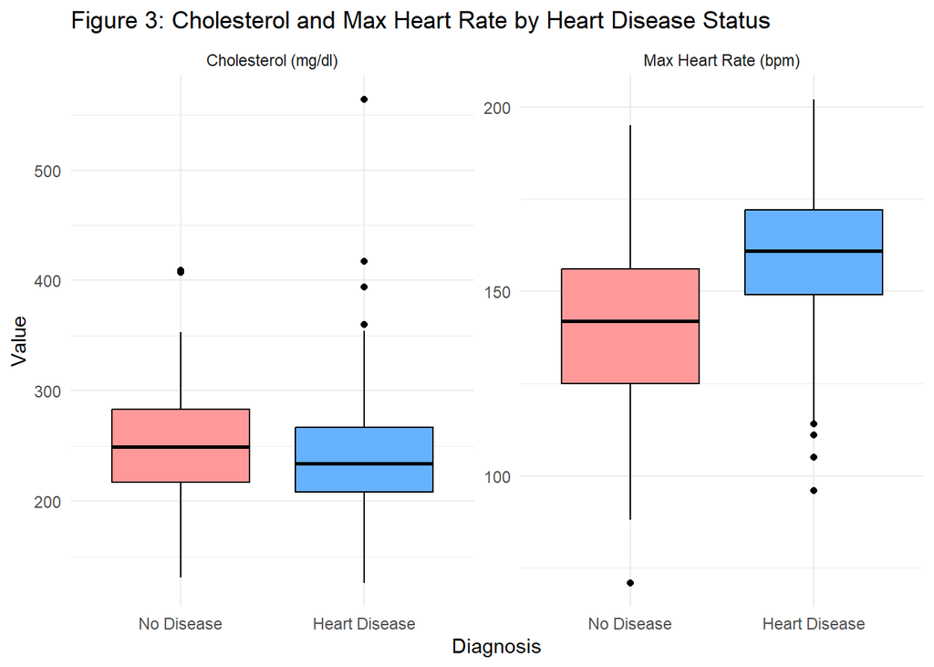

```r
# Figure 3 - Boxplots of cholesterol and max heart rate
chol_data <- data.frame(target = df$target, Value = df$chol, Variable = "Cholesterol (mg/dl)")
thalach_data <- data.frame(target = df$target, Value = df$thalach, Variable = "Max Heart Rate (bpm)")
plot3_data <- rbind(chol_data, thalach_data)

plot3 <- ggplot(plot3_data, aes(x = target, y = Value, fill = target)) +
  geom_boxplot(color = "black") +
  scale_fill_manual(values = c("No Disease" = "#FF9999", "Heart Disease" = "#66B2FF")) +
  facet_wrap(~Variable, scales = "free_y") +
  labs(
    title = "Figure 3: Cholesterol and Max Heart Rate by Heart Disease Status",
    x = "Diagnosis",
    y = "Value",
    fill = "Diagnosis"
  ) +
  theme_minimal() +
  theme(legend.position = "none")

print(plot3)
```

```r
ggsave("C:/Users/ADMIN/Documents/Bioinformatic-Project---2020-ASP-83/Output/figure3_boxplots.png",
       plot3, width = 8, height = 5)
```

[figure not shown]

```r
# Figure 4 - Correlation heatmap
numeric_df <- cor(df[, c("age", "trestbps", "chol", "thalach", "oldpeak", "ca")])

png("C:/Users/ADMIN/Documents/Bioinformatic-Project---2020-ASP-83/Output/figure4_heatmap.png",
    width = 2000, height = 1600, res = 200)
pheatmap(numeric_df,
         main = "Figure 4: Correlation Heatmap of Clinical Features",
         color = colorRampPalette(c("blue", "white", "red"))(50),
         display_numbers = TRUE,
         number_format = "%.2f",
         fontsize = 14)
```

```r
dev.off()
```

```r
pheatmap(numeric_df,
         main = "Figure 4: Correlation Heatmap of Clinical Features",
         color = colorRampPalette(c("blue", "white", "red"))(50),
         display_numbers = TRUE,
         number_format = "%.2f",
         fontsize = 14)
```

## 5. Statistical Tests

```r
# T-tests for continuous variables
t_age <- t.test(age ~ target, data = df)
t_chol <- t.test(chol ~ target, data = df)
t_thalach <- t.test(thalach ~ target, data = df)
t_trestbps <- t.test(trestbps ~ target, data = df)

cat("=== T-TEST RESULTS ===\n")
```

```
## === T-TEST RESULTS ===
```

```r
cat("\nAge p-value:", round(t_age$p.value, 4))
```

```
##
## Age p-value: 1e-04
```

```r
cat("\nCholesterol p-value:", round(t_chol$p.value, 4))
```

```
##
## Cholesterol p-value: 0.136
```

```r
cat("\nMax Heart Rate p-value:", round(t_thalach$p.value, 4))
```

```
##
## Max Heart Rate p-value: 0
```

```r
cat("\nBlood Pressure p-value:", round(t_trestbps$p.value, 4))
```

```
##
## Blood Pressure p-value: 0.0127
```

```r
# Chi-squared tests
chi_sex <- chisq.test(table(df$sex, df$target))
chi_cp <- chisq.test(table(df$cp, df$target))
chi_exang <- chisq.test(table(df$exang, df$target))

cat("\n\n=== CHI-SQUARED TEST RESULTS ===\n")
```

```
##
##
## === CHI-SQUARED TEST RESULTS ===
```

```r
cat("\nSex p-value:", round(chi_sex$p.value, 6))
```

```
##
## Sex p-value: 2e-06
```

```r
cat("\nChest Pain p-value:", round(chi_cp$p.value, 6))
```

```
##
## Chest Pain p-value: 0
```

```r
cat("\nExercise Angina p-value:", round(chi_exang$p.value, 6))
```

```
##
## Exercise Angina p-value: 0
```

## 6. Machine Learning Models

```r
# Fix factor levels and split data
set.seed(123)

df$target <- factor(df$target,
                    levels = c("No Disease", "Heart Disease"),
                    labels = c("NoDisease", "HeartDisease"))

trainIndex <- createDataPartition(df$target, p = 0.8, list = FALSE)
train_data <- df[trainIndex, ]
test_data <- df[-trainIndex, ]

cat("Training set rows:", nrow(train_data))
```

```
## Training set rows: 243
```

```r
cat("\nTest set rows:", nrow(test_data))
```

```
##
## Test set rows: 60
```

```r
# Logistic Regression
set.seed(123)

log_model <- train(target ~ .,
                   data = train_data,
                   method = "glm",
                   family = "binomial",
                   trControl = trainControl(method = "cv",
                                          number = 5,
                                          classProbs = TRUE))

log_pred <- predict(log_model, test_data)
log_cm <- confusionMatrix(log_pred, test_data$target)
print(log_cm)
```

```
## Confusion Matrix and Statistics
##
##               Reference
## Prediction     NoDisease HeartDisease
##   NoDisease           19            3
##   HeartDisease         8           30
##
##                Accuracy : 0.8167
##                  95% CI : (0.6956, 0.9048)
##     No Information Rate : 0.55
##     P-Value [Acc > NIR] : 1.344e-05
##
##                   Kappa : 0.6233
##
##  Mcnemar's Test P-Value : 0.2278
##
##             Sensitivity : 0.7037
##             Specificity : 0.9091
##          Pos Pred Value : 0.8636
##          Neg Pred Value : 0.7895
##              Prevalence : 0.4500
##          Detection Rate : 0.3167
##    Detection Prevalence : 0.3667
##       Balanced Accuracy : 0.8064
##
##        'Positive' Class : NoDisease
##
```

```r
# Random Forest
set.seed(123)

rf_model <- train(target ~ .,
                  data = train_data,
                  method = "rf",
                  trControl = trainControl(method = "cv",
                                         number = 5,
                                         classProbs = TRUE))

rf_pred <- predict(rf_model, test_data)
rf_cm <- confusionMatrix(rf_pred, test_data$target)
print(rf_cm)
```

```
## Confusion Matrix and Statistics
##
##               Reference
## Prediction     NoDisease HeartDisease
##   NoDisease           21            4
##   HeartDisease         6           29
##
##                Accuracy : 0.8333
##                  95% CI : (0.7148, 0.9171)
##     No Information Rate : 0.55
##     P-Value [Acc > NIR] : 3.483e-06
##
##                   Kappa : 0.661
##
##  Mcnemar's Test P-Value : 0.7518
##
##             Sensitivity : 0.7778
##             Specificity : 0.8788
##          Pos Pred Value : 0.8400
##          Neg Pred Value : 0.8286
##              Prevalence : 0.4500
##          Detection Rate : 0.3500
##    Detection Prevalence : 0.4167
##       Balanced Accuracy : 0.8283
##
##        'Positive' Class : NoDisease
##
```

```r
# SVM model
set.seed(123)

svm_model <- svm(target ~ .,
                 data = train_data,
                 kernel = "radial",
                 probability = TRUE)

svm_pred <- predict(svm_model, test_data)
svm_cm <- confusionMatrix(svm_pred, test_data$target)
print(svm_cm)
```

```
## Confusion Matrix and Statistics
##
##               Reference
## Prediction     NoDisease HeartDisease
##   NoDisease           20            5
##   HeartDisease         7           28
##
##                Accuracy : 0.8
##                  95% CI : (0.6767, 0.8922)
##     No Information Rate : 0.55
##     P-Value [Acc > NIR] : 4.67e-05
##
##                   Kappa : 0.5932
##
##  Mcnemar's Test P-Value : 0.7728
##
##             Sensitivity : 0.7407
##             Specificity : 0.8485
##          Pos Pred Value : 0.8000
##          Neg Pred Value : 0.8000
##              Prevalence : 0.4500
##          Detection Rate : 0.3333
##    Detection Prevalence : 0.4167
##       Balanced Accuracy : 0.7946
##
##        'Positive' Class : NoDisease
##
```

```r
# ROC curves
log_prob <- predict(log_model, test_data, type = "prob")[,2]
rf_prob <- predict(rf_model, test_data, type = "prob")[,2]
svm_prob_raw <- predict(svm_model, test_data, probability = TRUE)
svm_prob <- attr(svm_prob_raw, "probabilities")[,2]

roc_log <- roc(test_data$target, log_prob)
roc_rf <- roc(test_data$target, rf_prob)
roc_svm <- roc(test_data$target, svm_prob)

cat("Logistic Regression AUC:", round(auc(roc_log), 4))
```

```
## Logistic Regression AUC: 0.8664
```

```r
cat("\nRandom Forest AUC:", round(auc(roc_rf), 4))
```

```
##
## Random Forest AUC: 0.9001
```

```r
cat("\nSVM AUC:", round(auc(roc_svm), 4))
```

```
##
## SVM AUC: 0.8597
```

```r
png("C:/Users/ADMIN/Documents/Bioinformatic-Project---2020-ASP-83/Output/figure5_roc_curves.png",
    width = 1200, height = 900, res = 150)
plot(roc_log, col = "blue", lwd = 2, main = "Figure 5: ROC Curves for All Models")
plot(roc_rf, col = "red", lwd = 2, add = TRUE)
plot(roc_svm, col = "green", lwd = 2, add = TRUE)
legend("bottomright",
       legend = c(paste("Logistic Regression AUC =", round(auc(roc_log), 3)),
                  paste("Random Forest AUC =", round(auc(roc_rf), 3)),
                  paste("SVM AUC =", round(auc(roc_svm), 3))),
       col = c("blue", "red", "green"), lwd = 2)
dev.off()
```

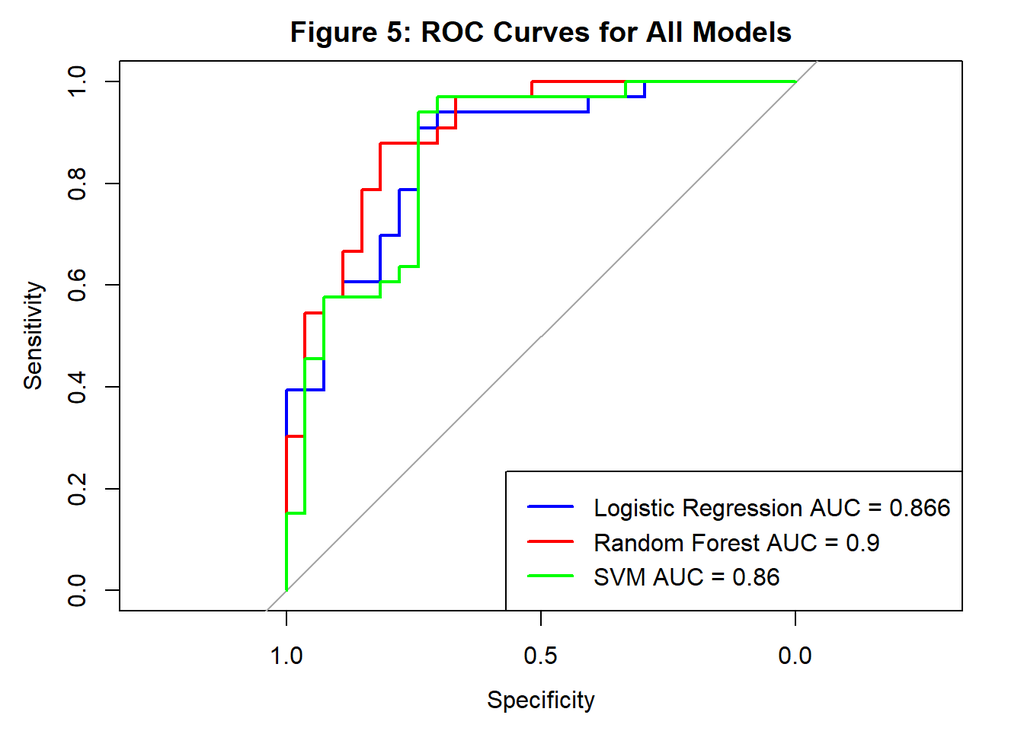

```r
plot(roc_log, col = "blue", lwd = 2, main = "Figure 5: ROC Curves for All Models")
plot(roc_rf, col = "red", lwd = 2, add = TRUE)
plot(roc_svm, col = "green", lwd = 2, add = TRUE)
legend("bottomright",
       legend = c(paste("Logistic Regression AUC =", round(auc(roc_log), 3)),
                  paste("Random Forest AUC =", round(auc(roc_rf), 3)),
                  paste("SVM AUC =", round(auc(roc_svm), 3))),
       col = c("blue", "red", "green"), lwd = 2)
```

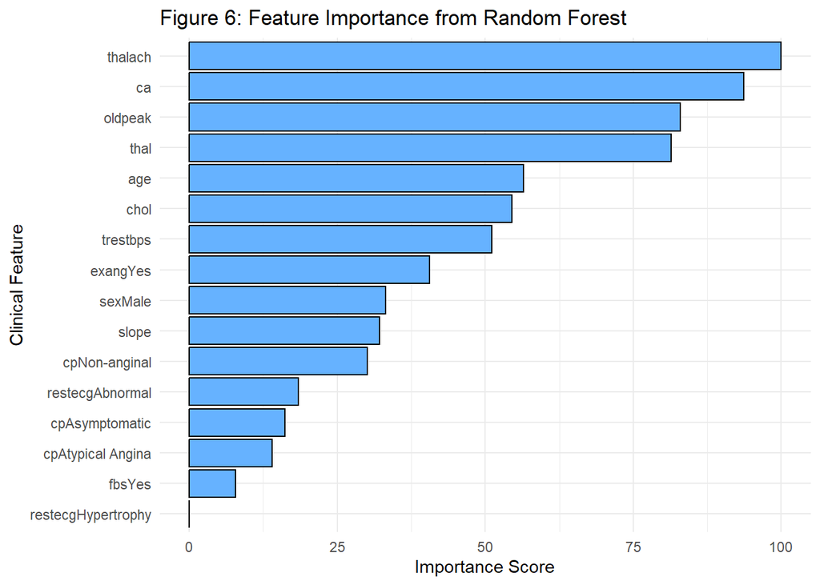

```r
# Feature Importance
importance_data <- varImp(rf_model)$importance
importance_data$Feature <- rownames(importance_data)
importance_data <- importance_data[order(importance_data$Overall, decreasing = TRUE),]

plot6 <- ggplot(importance_data, aes(x = reorder(Feature, Overall), y = Overall)) +
  geom_bar(stat = "identity", fill = "#66B2FF", color = "black") +
  coord_flip() +
  labs(title = "Figure 6: Feature Importance from Random Forest",
       x = "Clinical Feature", y = "Importance Score") +
  theme_minimal()

print(plot6)
```

```r
ggsave("C:/Users/ADMIN/Documents/Bioinformatic-Project---2020-ASP-83/Output/figure6_feature_importance.png",
       plot6, width = 8, height = 5, dpi = 300)
```

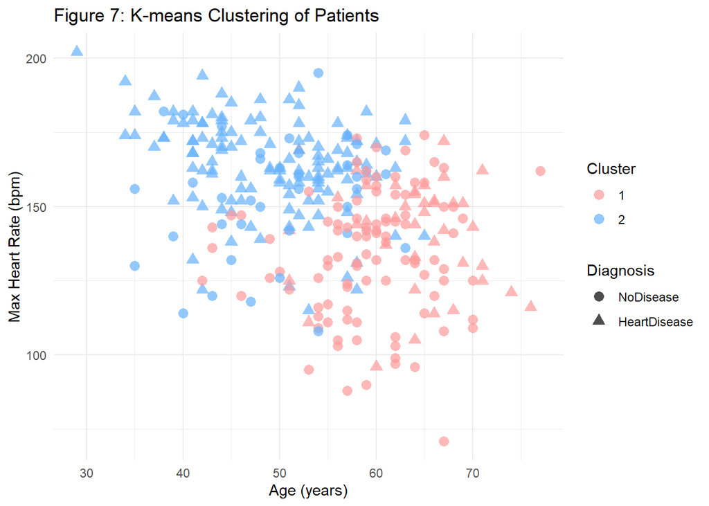

```r
# K-means clustering
set.seed(123)

cluster_data <- df[, c("age", "trestbps", "chol", "thalach", "oldpeak", "ca")]
scaled_data <- scale(cluster_data)
km <- kmeans(scaled_data, centers = 2, nstart = 25)
df$cluster <- factor(km$cluster)

plot7 <- ggplot(df, aes(x = age, y = thalach, color = cluster, shape = target)) +
  geom_point(size = 3, alpha = 0.7) +
  scale_color_manual(values = c("1" = "#FF9999", "2" = "#66B2FF")) +
  labs(title = "Figure 7: K-means Clustering of Patients",
       x = "Age (years)", y = "Max Heart Rate (bpm)",
       color = "Cluster", shape = "Diagnosis") +
  theme_minimal()

print(plot7)
```

```r
ggsave("C:/Users/ADMIN/Documents/Bioinformatic-Project---2020-ASP-83/Output/figure7_clustering.png",
       plot7, width = 8, height = 5, dpi = 300)
```

## 9. Reproducibility

To reproduce this analysis: 1. Clone the repository from GitHub 2. Install R packages: ggplot2, caret, e1071, pheatmap, pROC, randomForest 3. Run Data/download.R to download the dataset 4. Open Code/analysis.Rmd in RStudio and click Knit to HTML

## 10. References

- Detrano, R., et al. (1989). International application of a new probability algorithm for the diagnosis of coronary artery disease. American Journal of Cardiology, 64(5), 304-310.
- UCI Machine Learning Repository. Heart Disease Dataset. https://archive.ics.uci.edu/dataset/45/heart+disease
- R Core Team (2024). R: A language and environment for statistical computing.
- Kuhn, M. (2008). Building predictive models in R using the caret package. Journal of Statistical Software, 28(5).